# Positive effects of ants on host trees are critical in years of low reproduction and not influenced by liana presence - ScienceDirect

- [View **PDF**](https://www.sciencedirect.com/science/article/pii/S1439179122000470/pdfft?md5=ca158150365c12c06721aec5b4c000a4&pid=1-s2.0-S1439179122000470-main.pdf)

## Figures (3)

## Tables (1)

1. Table 1

## Extras (1)

1. Document

[figure not shown]

## [Basic and Applied Ecology](https://www.sciencedirect.com/journal/basic-and-applied-ecology)

[Volume 63](https://www.sciencedirect.com/journal/basic-and-applied-ecology/vol/63/suppl/C), September 2022, Pages 93-103

# RESEARCH PAPER Positive effects of ants on host trees are critical in years of low reproduction and not influenced by liana presence

[Glória RamosSoares<sup>a</sup><sup>b</sup><sup>#</sup>](https://www.sciencedirect.com/science/article/pii/S1439179122000470?via%3Dihub#!)[Diego VAnjos<sup>c</sup><sup>#</sup>](https://www.sciencedirect.com/science/article/pii/S1439179122000470?via%3Dihub#!)[Fernanda Vieirada Costa<sup>d</sup>](https://www.sciencedirect.com/science/article/pii/S1439179122000470?via%3Dihub#!)[Giselle MartinsLourenço<sup>a</sup><sup>e</sup>](https://www.sciencedirect.com/science/article/pii/S1439179122000470?via%3Dihub#!)[Ricardo IldefonsoCampos<sup>b</sup>](https://www.sciencedirect.com/science/article/pii/S1439179122000470?via%3Dihub#!)[Sérvio PontesRibeiro<sup>a</sup><sup>e</sup>](https://www.sciencedirect.com/science/article/pii/S1439179122000470?via%3Dihub#!)

https://doi.org/10.1016/j.baae.2022.05.008[Get rights and content](https://s100.copyright.com/AppDispatchServlet?publisherName=ELS&contentID=S1439179122000470&orderBeanReset=true)

Under a Creative Commons [license](https://creativecommons.org/licenses/by-nc-nd/4.0/)

Open access

## Highlights

**•**

*[Azteca](https://www.sciencedirect.com/topics/agricultural-and-biological-sciences/azteca)* *chartifex* decreased leaf herbivory and increased *B. sericea* flower-fruit conversion irrespective of [lianas](https://www.sciencedirect.com/topics/agricultural-and-biological-sciences/liana) presence.

**•**

A positive effect of ants was detected only in the second year of the experiment, consistently on all plants at each experimental level.

**•**

Liana removal had no effect on *A. chartifex* foraging and on leaf herbivory and flower-fruit conversion of host plants.

**•**

Dominant arboreal ants can benefit plants even in a non-obligatory interaction.

## Abstract

Tropical tree-climbing lianas form paths that benefit foraging of dominant ants which might protect the host tree against herbivores. In contrast, lianas are often associated with negative effects on growth and reproduction of host trees due to light obstruction, structural stress and other negative effects. It is unclear if dominant ants could mitigate the negative effects of lianas on host plants. We investigated how lianas and carton nest ants (*Azteca chartifex*) affected herbivory and reproductive structures of the host tree *Byrsonima sericea*. Considering 68 trees, almost half of them were naturally colonized by *A. chartifex* nests (32 trees). We removed lianas from half of the trees (34), establishing a factorial sampling design between *A. chartifex* and liana presence. We sampled ants and leaf herbivory before and after removing lianas, and measured plant fitness in two consecutive years after removing lianas. Liana removal had no effect on *A. chartifex* foraging, on leaf herbivory and flower-fruit conversion of host plants. However, *A. chartifex* decreased leaf herbivory and increased *B. sericea* flower-fruit conversion irrespective of lianas presence. A noticeable positive effect of ants was detected only in the second year of the experiment, consistently on all plants at each experimental level. The reproductive conditions of the first year resulted in most plants with more than 75% flower-to-fruit conversion success, regardless of the presence of *A. chartifex*, a success sustained only on those ant-colonized plants in the second year. Our results contribute to understanding multi-trophic interactions in tropical forest canopies as we demonstrated i) that dominant arboreal ants can benefit plants even in a non-obligatory interaction and ii) that the influence of lianas on its host tree is context-dependent, presenting even neutral effects depending on habitat type and species involved.

## Keywords

Ant–plant mutualisms

Canopy

Plant fitness

Herbivory

Multi-trophic interactions

Woody vines

## Introduction

Ecological interactions are considered major drivers of plant fitness (Del-Claro et al., 2018; Herrera et al., 2002; Thompson, 2005). Tropical trees may interact with a myriad of species resulting in a large range from positive to negative effects on plant resource acquisition (Dáttilo & Rico-Gray, 2018; Thompson, 2005). Two species assemblages with contrasting effects on tropical trees are 1) the [lianas](https://www.sciencedirect.com/topics/agricultural-and-biological-sciences/liana), which can parasite up to 75% of trees in tropical forests, depending on disturbance (Ingwell, Joseph Wright, Becklund, Hubbell & Schnitzer, 2010) and 2) the ants, which make up to 25% of animal biomass in tropical forests (Hölldobler & Wilson, 1990). While lianas act as wood climbers and can cause direct negative effects on host plants, such as light obstruction, structural stress, hampering sap conduction and others (Ingwell et al., 2010; Putz, 1984; Putz & Mooney, 1992; Schnitzer, 2018; Schnitzer & Carson, 2010; van der Heijden & Phillips, 2009), ants, by means of an aggressive patrolling behavior, might decrease leaf herbivory and increase plant performance (Rosumek et al., 2009; Trager et al., 2010). Despite being overlooked, to disentangle the contrasting effects of lianas and ants on plant fitness would help to understand how this multi-trophic interaction could influence the tree reproductive success and [forest regeneration](https://www.sciencedirect.com/topics/agricultural-and-biological-sciences/forest-regeneration).

Lianas are especially important for dominant ant species that require abundant resources to maintain large and often polydomous colonies (e.g., belonging to *[Azteca](https://www.sciencedirect.com/topics/agricultural-and-biological-sciences/azteca)* and *[Crematogaster](https://www.sciencedirect.com/topics/agricultural-and-biological-sciences/crematogaster)* genera) (Holldobler & Wilson, 1990). Lianas can be used by ants to expand foraging area and patrolling efficiency (Clay, Bauer, Solis, & Yanoviak, 2010) and as a source of extra-floral nectar (EFN) (Bluthgen & Fiedler, 2002), increasing ant species richness on host plants (Adams, Schnitzer & Yanoviak, 2017). Therefore, lianas might be even more important to dominant ants, which present populous colonies and display aggressive behavior characterized by inter- and intraspecific confrontations to defend resources and territory (e.g., host plants) (Dejean, Corbara, Orivel & Leponce, 2007). Ant protection effectiveness on plants may depend on the resources offered by the host plants or by associated lianas (e.g., nesting sites and food resources such as EFN or trophobionts) which can mediate mutualistic interactions (Fagundes et al., 2017; Ness, Morris & Bronstein, 2006). In ant-plant mutualism, the ants often decrease leaf herbivory and increase the fitness of host plant (Rosumek et al., 2009; Trager et al., 2010). However, for non-obligatory (facultative) ant-plant interactions, which have been neglected in the literature, the effect of ants on hebivory levels is contrasting (Brenes-Arguedas, Coley & Kursar, 2007; Itino & Itioka, 2001; Kaplan, Halitschke, Kessler, Sardanelli & Denno, 2008). Further, how do ants impact the fitness of unattractive plants is not known. As lianas are highly frequent plants living on trees in tropical forests (Ingwell et al., 2010), they likely influence the outcome of ant-host plant interactions.

Thus, based on this natural multi-trophic laboratory, our aim is to experimentally investigate how lianas affect the herbivory and reproduction of *B. sericea*, comparing trees with and without nests of the ant *A. chartifex*. Our study addresses three hypotheses: (1) The presence of lianas positively affects *A. chartifex* foraging on *B. sericea*; (2) The presence of *A. chartifex* and lianas negatively influences leaf herbivory on *B. sericea*; and (3) The presence of *A. chartifex* and lianas has contrasting effects (positive and negative, respectively) on *B. sericea* reproduction. However, as the lianas are the main connections between trees in the forest (Odell, Stork & Kitching, 2019; Yanoviak, 2015), *A. chartifex* should increase foraging by traveling longer distances to protect its territory when lianas are present (Clay et al., 2010). Therefore, we expected the widely described negative effects of lianas (Ingwell et al., 2010; Putz, 1984; Putz & Mooney, 1992; Schnitzer, 2018; Schnitzer & Carson, 2010; van der Heijden & Phillips, 2009) to be mitigated by enhancing the positive effects of ants against herbivores (Rosumek et al., 2009; Trager et al. 2010), consequently favoring the reproductive success of *B. sericea*.

## Materials and methods

### Study area

The study was conducted in the Rio Doce State Park (PERD in Portuguese acronym) (19˚48’-19˚29’S and 42˚38’- 42˚28’W), in Minas Gerais State, southeastern Brazil. The climatic regime of the region is tropical seasonal (Aw), according to Köppen's classification (Alvares, Stape, Sentelhas, de Moraes Gonçalves & Sparovek, 2013). The climatic regime is well defined with two seasons: the dry period between May-September and the rainy season between October-April. Average precipitation is around 1,500 mm per year (Alvares et al., 2013). The PERD covers an area of approximately 36,000 ha of Atlantic Forest varying from 200 and 500 m above sea level and it comprises the largest natural neotropical lake system. About 11% of the park is covered by 42 lakes, in spite of the young evolutionary history of the forest (Fonseca-Silva, Carvalho & Ribeiro, 2015, 2019).

The park encompasses a vast [ecotone](https://www.sciencedirect.com/topics/agricultural-and-biological-sciences/ecotones) of forest-lake zones with high sun light availability, resulting in the formation of trees with main branches that grow bent towards the lakes at 1-3 meters above the ground. This results in what has been called ‘brought-low canopy’ (Lourenço et al., 2019), which is, strictly speaking, a typical canopy habitat lying close to the ground, on the ecotone shore or over the lakes’ margin. PERD is an International Long-Term Ecological Research site (ILTER) whose tree-arthropod systems have been investigated since 2002 (Campos, Soares, Martins & Ribeiro, 2006; Campos, Vasconcelos, Ribeiro, Neves & Soares, 2006; Coelho & Ribeiro, 2006; Ribeiro et al., 2008; Dolabela et al., 2022). Our group has described that ecotones between forest and natural lakes in the Atlantic Forest keep typical upper canopy traits, due to whole crowns being bent towards the water (Barbosa, 2014). Upper canopy leaves present a high degree of sclerophylly and typical morphological attributes caused by high insolation and lower nutrient quality (Ribeiro & Basset, 2007, 2016; Sanches et al., 2010), as in the lake´s brought-low canopy (Pinto et al., 2021). Additionally, brought-low canopy leaves have rates of leaf respiration similar to those of emergent trees (Sanches et al., 2010) and the [crown architecture](https://www.sciencedirect.com/topics/earth-and-planetary-sciences/canopy-architecture) is typical of a canopy tree (e.g., trunk-leaf biomass ratio, qualitative data on leaf characteristics and trunk ramifications) (Barbosa, 2014; Pinto et al., 2021). Such forests are occupied by typical canopy insects (Lourenço et al., 2019) and fully taken by *[Azteca](https://www.sciencedirect.com/topics/agricultural-and-biological-sciences/azteca)* *chartifex* (Campos et al., 2006). Due to this ‘brought-low canopy’, the lake shores in PERD provide easy canopy access, likely to be properly sampled with a ladder and basic security climbing gears, as allow to produce a comprehensive and replicated experiment.

### Study system

*Azteca chartifex* Emery, 1896 (Formicidade: Dolichoderinae) is a territorial, dominant, and polydomic ant that belongs to a strictly neotropical group of arboreal ants (Longino, 2007). The nests of *A. chartifex* are structurally based on cellulose and processed fibers (i.e., carton nest), and may contain up to a million individuals (Baccaro et al., 2015; Wheeler, 1986). *Azteca chartifex* has a non-obligatory mutual association with *B. sericea*, establishing the main nest pending in its trunk and numerous smaller satellite nests distributed along the branches. The satellite nests usually present only workers (Miranda et al., 2021). For instance, on the trees presenting *A. chartifex* nests in our field area we counted on average 23 (SE = 1.58) satellite nests (4 - 15 cm) per tree (3.45 - 7.99 m height; 5.95 ± 0.20, mean ± SE) in a radius of 8 m around the main nest (n = 32). Considering nest sizes, we specified that the average size was taken from a sample of satellites reachable by climbing. We performed our counting with two independent samplers (always the same ones) using binoculars (one climbing the tree and one in the ground). These two samplers simultaneously counted the satellite nests across the crown in each tree. Thus, we estimated the total number of satellite nests per tree by averaging each sampler blind counting. In the PERD, we observed that when *A. chartifex* is present, *B. sericea* trees within its territory are constantly foraged by a large number of *A. chartifex* workers.

*[Byrsonima](https://www.sciencedirect.com/topics/agricultural-and-biological-sciences/byrsonima)* *sericea* predominates in the vegetation in forest-lake ecotone inside PERD, making it a dominant long-lived leaves species, with sclerophyllous leaves and a complex crown architecture (e.g., height, trunk diameter, number of growth units and number of leaves) (Barbosa, 2014; Pinto et al., 2021). Although of some level of sclerophylly, *B. sericea* also has leaves with high levels of nitrogen (Pinto et al., 2021). In these forest-lake ecotones, *B. sericea* crowns grow towards the lakes, positioning at the same height of understory stratum. [Flowering](https://www.sciencedirect.com/topics/agricultural-and-biological-sciences/anthesis) and fruiting of *B. sericea* occur from late October until the end of April (Teixeira & Machado, 2000). This species does not produce EFNs. *Byrsonima sericea* trees selected in our study site have a mean volume of 6,79 leaves/m<sup>3</sup>, mean height of 5.68 m (± 0.13 SE), and mean diameter at breast height of 59 cm (± 3 SE) (n = 68). All *B. sericea* individuals that occur in ecotone areas of PERD host [lianas](https://www.sciencedirect.com/topics/agricultural-and-biological-sciences/liana) in their crowns (about 10 species of lianas), which spread on the canopy of forest ecotones. An average of 75% of *B. sericea* crown area (± 30% SE) is occupied by lianas and these are used by *A. chartifex* as routes for maximizing their foraging.

### Experimental design

We arbitrarily selected 68 individuals of *Byrsonima sericea*, distributed among three distinct forest-lake ecotone sites (Fig. 1). All *B. sericea* trees were between 3.45 and 7.99 m high and grew on sunny lake borders with similar light availability. All studied tree individuals had lianas in their crowns. Thirty-two trees were naturally colonized by *Azteca chartifex* and while 36 were not. We considered “colonized trees” individuals that carried the main *A. chartifex* nest or at least five active satellite nests on its crown (n = 32). Trees without nests were classified as “uncolonized trees” (n = 36). Field experiment was carried out in three phases: phase I in March 2016 (only ant effects), phase II in August 2016 (liana removal experiment), and phase III in March 2017 (complete experimental design). In phase I, we divided all 68 trees into two groups: “colonized trees” and “uncolonized trees”, only to detect *A. chartifex* effects (see details below). In phase II, we randomly selected half of the *B. sericea* individuals from phase I (34 of the 68 trees), including colonized and uncolonized trees, and experimentally removed the lianas from their crowns (those plants were then considered as “lianas removed”); the remaining individuals were not manipulated and thus considered as “lianas present” (see Fig. 1). Thus, in phase II we had our complete experimental design as follow: i) colonized trees with lianas present (n = 16), ii) uncolonized trees with lianas present (n = 18), iii) colonized trees with lianas removed (n = 16), and iv) uncolonized trees with lianas removed (n = 18) (Appendix A: “Experimental design details”). We cut-off all lianas from the 34 trees starting at 2 m from ground level using machetes, tree pruner, and [pruning shears](https://www.sciencedirect.com/topics/agricultural-and-biological-sciences/pruning-shears), and then removed lianas’ aerial parts with a ladder, or climbing if necessary. After liana removal, we visited all patches bi-monthly for the next 18 months to monitor *B. sericea* individuals and cut-off the re-sprouting liana shoots in all the individuals of the “lianas removed” group. Finally, in phase III we sampled ant diversity and leaf herbivory from all the 68 tree individuals (see details below) in the same experimental design of phase II.

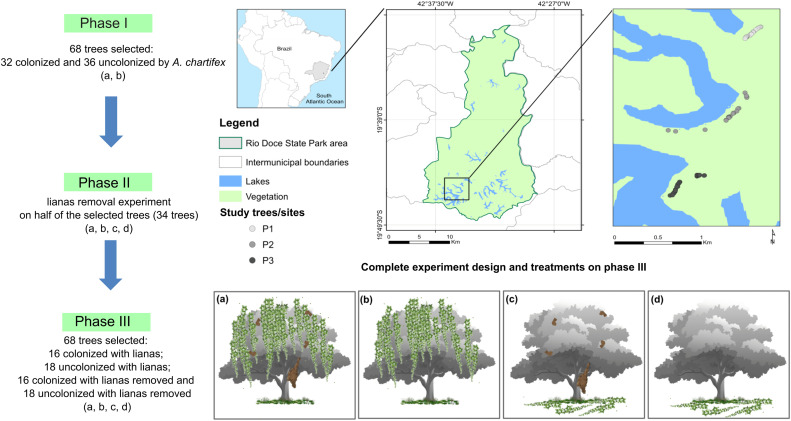

1. [Download : Download high-res image (704KB)](https://ars.els-cdn.com/content/image/1-s2.0-S1439179122000470-gr1_lrg.jpg)
2. [Download : Download full-size image](https://ars.els-cdn.com/content/image/1-s2.0-S1439179122000470-gr1.jpg)

### Ant foraging activity and herbivory

In phase III, after lianas removal experiment, we sampled ants and leaves (for herbivory analysis) in crowns of all 68 *B. sericea* individuals with the aid of an aluminum ladder (max. 5 m high) and basic climbing security gears. We sampled ants using entomological umbrellas and performing the beating technique (Ribeiro et al., 2005). For this, in each tree we randomly selected three branches and performed 10 beats per branch with a beating stick (selected branches had approximately the same number of leaves) in order to dislodge the associated ants onto a tray placed beneath. Ants were identified with the aid of [taxonomic keys](https://www.sciencedirect.com/topics/agricultural-and-biological-sciences/taxonomic-keys) (Baccaro et al., 2015) and comparing specimens with the collection of the ‘Laboratory of Ecology of Diseases & Forests’ at the Universidade Federal de Ouro Preto, Minas Gerais State, Brazil. In addition, we had assistance of a taxonomist (Dr. Rodrigo Feitosa). On uncolonized trees we only sampled non-*Azteca chartifex* ants. Overall, as the richness and abundance of non-*Azteca chartifex* ants were low (in all 68 trees sampled: richness: 1.88 ± 0.22; abundance: 7.08 ± 1.63, mean and SE, N = 68), probably due to the aggressiveness and territorialism of the *A. chartifex* (see Philpott, Serber & De la Mora, 2018), these data were excluded from the following analyses. Vouchers were deposited at the above-mentioned laboratory. Licenses for the field studies were issued by the state authority ‘Instituto Estadual de Florestas (IEF)’ and the national authority ‘Sistema de Autorização e Informação em Biodiversidade/ Instituto Chico Mendes de Conservação da Biodiversidade (SISBIO/ ICMBio) (SISBIO authorization number 55058-1, IEF authorization 088/2016)’.

We collected the leaves to estimate herbivory level (phase III) with the guidance of a 0.027 m<sup>3</sup> wire-framed cube (Appendix A: Fig. 1) positioned at three distinct points inside the crowns (adapted from Ribeiro & Basset, 2007; Shaw, Ernest, Rinker & Lowman, 2006). This methodology aims to guarantee a real random leaf sampling. In order to better represent tree herbivory, we positioned the cube using a ladder and climbing devices and randomly sampled three regions inside crowns. We collected all leaves that were inside the cube (mean = 183 leaves, N = 68 trees), resulting in a final volume of 0.081 m<sup>3</sup> and approximately 550.58 ± 28.90 leaves (mean ± SE) per tree. These leaves were digitalized and analyzed in the ImageJ software (Schneider, Rasband & Eliceiri, 2012). The percentage of herbivory per leaf was calculated as (leaf area removed x 100)/(total leaf area) using the software ImageJ. Individual percentages were then averaged for each sampled plant. Finally, in phase III we sampled *A. chartifex* foraging activity on *B. sericea* branches. The foraging activity was measured by counting the number of *A. chartifex* individuals collected by beating sampling.

### Data analysis

Using data from the complete experimental design (phase III), we used Generalized Linear Models (GLM) assuming quasi-Poisson error distribution to test whether *A. chartifex* foraging activity (i.e., number of workers per host plant) is affected by liana presence on colonized trees (hypothesis 1). For this first model, we considered *A. chartifex* foraging activity as response variable and liana presence (lianas present or removed) as explanatory variables.

Our second model was a Generalized Linear Mixed Model (GLMM) assuming beta error distribution (Ferrari & Cribari-Neto, 2004) and it was built to test the effect of lianas and *A. chartifex* foraging activity on colonized trees (explanatory variables) and their interaction on herbivory levels on *B. sericea* (response variable) (hypothesis 2). As our third model, we also tested the effect of lianas and *A. chartifex* presence (colonized and uncolonized trees), and their interaction on herbivory levels of *B. sericea* using Generalized Linear Mixed Model (GLMM) assuming beta error distribution (Ferrari & Cribari-Neto, 2004) (hypothesis 2). For the third model, we considered the presence of lianas and *A. chartifex* presence as explanatory variables and herbivory as response variable. In these two latter models, we considered the tree patches (see Fig. 1) as a random variable.

Finally, we built a fourth Generalized Linear Mixed Model (GLMM), assuming a beta-binomial error distribution (Brooks et al., 2017) to test whether the presence of *A. chartifex*, lianas and the year of sampling (2017 and 2018), and their interactions (explanatory variables) affect the reproductive success (flower to fruit conversion) (response variable) of *B. sericea* pooling together the data from both reproductive seasons (2017 and 2018) (hypothesis 3)*.* For this fourth model we used tree identity nested within treatment as random effect. To measure reproductive success (response variable), we combined the number of successes (representing the maximum number of infructescences recorded in each plant) and number of failures (maximum number of inflorescences recorded minus the maximum number of infructescences) using “cbind” function on software R (version 4.0.0) (R Core Team, 2020) as proportion of successful flower to fruit conversions. The residuals of all models were analyzed to verify the adequacy of the models (Crawley, 2013) using the “DHARMa” package (Hartig, 2017). All analyses were conducted in the software R (version 4.0.0) (R Core Team, 2020) using the “lme4” and “glmmTMB” package (Bates, Mächler, Bolker & Walker, 2015; Brooks et al., 2017).

## Results

### Effect of ants and lianas on herbivory

There was no effect of liana presence on *A. chartifex* foraging activity (F<sub>1,30</sub> = 1.54, p = 0.22). The trees with [lianas](https://www.sciencedirect.com/topics/agricultural-and-biological-sciences/liana) had on average 68.81 ± 74.19 individuals of *A. chartifex*, while the trees without lianas harbored 42.25 ± 37.19 individuals (Appendix A: Fig. 2). Liana removal also had no effect on herbivory, irrespective of ant presence (χ<sup>2</sup>= 0.40, p = 0.52, N = 68) (Fig. 2A) or ant foraging activity (χ<sup>2</sup>= 0.37, p = 0.53, N = 32) (Fig. 2B). The presence of *A. chartifex* had no effect on herbivory (χ<sup>2</sup>= 1.72, p = 0.18, N = 68). However, the foraging activity of *A. chartifex* had a negative effect on herbivory (χ<sup>2</sup>= 4.68, p = 0.03, N = 32) (Fig. 2B). The abundance of *A. chartifex* was able to reduce herbivory enormously (8.6% to 0.05%, maximum and minimum herbivory level; mean = 2.77%; SE = 0.33%). Finally, there was no interactive effect of lianas presence and i) ant presence or ii) foraging activity on herbivory (χ<sup>2</sup>= 0.02, p = 0.86, N = 64; χ<sup>2</sup>= 0.16, p = 0.68, N = 32, respectively).

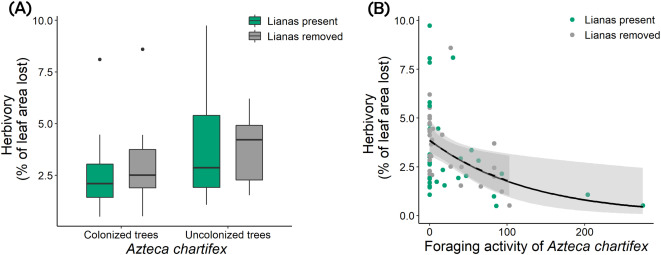

1. [Download : Download high-res image (280KB)](https://ars.els-cdn.com/content/image/1-s2.0-S1439179122000470-gr2_lrg.jpg)
2. [Download : Download full-size image](https://ars.els-cdn.com/content/image/1-s2.0-S1439179122000470-gr2.jpg)

Fig. 2. (A) [Herbivory](https://www.sciencedirect.com/topics/earth-and-planetary-sciences/herbivory) (percentage of leaf area lost) in trees colonized by *[Azteca](https://www.sciencedirect.com/topics/agricultural-and-biological-sciences/azteca)* *chartifex* with and without [lianas](https://www.sciencedirect.com/topics/agricultural-and-biological-sciences/liana), and uncolonized *A. chartifex* with and without lianas. Vertical lines represent the first and fourth [quartiles](https://www.sciencedirect.com/topics/earth-and-planetary-sciences/quartile), the boxes represent the second and third quartiles and the lines within the boxes represent the median. Points outside the boxplots represent atypical data. (B) Negative effect of foraging activity of *A. chartifex* on herbivory in the trees with or without lianas. The shaded area represents the 95% confidence interval. Curves were fitted with GLMM coefficients.

### Effect of lianas and ants on B. sericea reproductive success

Overall, considering all trees (irrespective of liana and *A. chartifex* presence), there was a reduction in flower/fruit conversion from 2017 (0.89 ± 0.02, N = 67) to 2018 (0.61 ± 0.04, N = 63). This pattern was consistent for plants in all patches (Appendix A: Table 1). We did not find isolated effect of lianas (χ<sup>2</sup> = 0.33, p = 0.56, N = 130), *A. chartifex* (χ<sup>2</sup> = 1.21, p = 0.27, N = 130) and year of sampling (χ<sup>2</sup> = 2.00, p = 0.15, N = 130) in flower/fruit conversion. However, there was a significant interaction between *A. chartifex* presence and year of sampling on flower/fruit conversion rate (χ<sup>2</sup> = 4.39, p = 0.03, N = 130) (Fig. 3). These results indicate that especially in the year with a reduced reproductive success (2018 compared to 2017), the trees colonized by ants, irrespective of liana presence, suffered a smaller decrease (2 x less) in flower/fruit conversion (19% decrease from 2017 to 2018) than uncolonized trees (45% decrease from 2017 to 2018). Hence, a noticeable positive effect of ants was detected only in the second year of the experiment, consistently to all plants (irrespective of liana presence). The reproductive conditions of the first year resulted that most trees had more than 75% conversion success, regardless of the present of *A. chartifex*, a success sustained only in the trees with ants in the second year (Fig. 3). Finally, we did not find any significant interaction at third level (Table 1).

Table 1. Results of Generalized Linear Model (GLM) (hypothesis 1) and Generalized Linear Mixed Models (hypotheses 2 and 3). Significance of all models was assessed by analysis of variance with ANOVA Type III. Significant predictors are in bold.

| Models | *F* or χ<sup>2</sup> value | Standard error | *Df* | *P* |
| --- | --- | --- | --- | --- |
| *Hypothesis 1* | F |  |  |  |
| *A. chartifex* foraging × Lianas | 1.54 | 0.37 | 1 | 0.22 |
| *Hypothesis 2* | χ<sup>2</sup> |  |  |  |
| *A. chartifex* presence | 1.72 | 0.18 | 1 | 0.18 |
| Lianas | 0.40 | 0.18 | 1 | 0.52 |
| *A. chartifex* presence × Liana | 0.02 | 0.24 | 1 | 0.86 |
| *A. chartifex* foraging | **4.68** | **> 0.01** | **1** | **0.03** |
| Lianas | 0.37 | 0.12 | 1 | 0.53 |
| *A. chartifex* foraging × Liana | 0.16 | > 0.01 | 1 | 0.68 |
| *Hypothesis 3* |  |  |  |  |
| *A. chartifex* foraging | 1.21 | 0.71 | 1 | 0.27 |
| Lianas (L) | 0.33 | 0.74 | 1 | 0.56 |
| Year (Y) | 2.00 | 0.64 | 1 | 0.15 |
| *A. chartifex* foraging × L | 0.38 | 0.97 | 1 | 0.53 |
| *A. chartifex* foraging × Y | **4.39** | **0.84** | **1** | **0.03** |
| L × Y | 0.13 | 0.92 | 1 | 0.71 |
| *A. chartifex* foraging × L × Y | 0.63 | 1.21 | 1 | 0.42 |

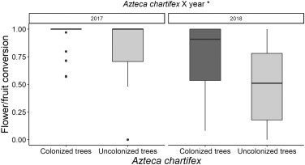

1. [Download : Download high-res image (102KB)](https://ars.els-cdn.com/content/image/1-s2.0-S1439179122000470-gr3_lrg.jpg)
2. [Download : Download full-size image](https://ars.els-cdn.com/content/image/1-s2.0-S1439179122000470-gr3.jpg)

Fig. 3. Flower/fruit conversion (fintness) in trees colonized by *[Azteca](https://www.sciencedirect.com/topics/agricultural-and-biological-sciences/azteca)* *chartifex* and uncolonized trees in the reproductive seasons 2017 and 2018. Vertical lines represent the first and fourth [quartiles](https://www.sciencedirect.com/topics/earth-and-planetary-sciences/quartile), the boxes represent the second and third quartiles and the lines within the boxes represent the median. There was a significant interaction between *A. chartifex* presence and year regarding flower/fruit conversion rate (χ<sup>2</sup> = 4.39, p = 0.03, N = 130). This significant value is indicated by the asterisk.

## Discussion

Our findings revealed that the carton [nest ant](https://www.sciencedirect.com/topics/agricultural-and-biological-sciences/ant-nests), *[Azteca](https://www.sciencedirect.com/topics/agricultural-and-biological-sciences/azteca)* *chartifex* showed at the same time a negative influence on leaf herbivory and a positive influence on reproductive success of *B. sericea* tree. These positive effects of ants on plant fitness emerged strongly when the trees experienced a weaker reproductive season. Interestingly and contrary to our expectations liana removal had no effect on *A. chartifex* foraging, leaf herbivory and plant fitness. Our results contribute to understanding the outcomes of multi-trophic interactions in tropical [forest canopies](https://www.sciencedirect.com/topics/agricultural-and-biological-sciences/forest-canopy) such as tree reproductive success and [forest regeneration](https://www.sciencedirect.com/topics/agricultural-and-biological-sciences/forest-regeneration).

Although lianas often attract a diverse fauna of invertebrates (both herbivores and their natural enemies) (Estrada-Villegas & Schnitzer, 2018), lianas in our system did not enhance foraging of *A. chartifex*. Many ant species may use lianas as nesting sites and/or to access EFN or other food sources (Bentley, 1981). In our case, as *A. chartifex* build carton nests, they use more resistant trunks and branches of the host plant to build their nests. Although the use of lianas as trails by ants, promoting connections among tree crowns (Gordon, 2017), their presence did not lead to increased ant foraging. Similar findings from a field experiment considering vine-like vegetation showed that ants discovered baits sooner with lianas present, but this did not imply an increase of ant species richness (Clay et al., 2010). Further, an experimental study in the Brazilian savanna indicates that ant species richness and composition were similar among different levels of canopy connectivity (Powell, Costa, Lopes & Vasconcelos, 2011).

We also found that liana presence did not influence leaf herbivory on trees. This pattern may be because lianas did not attract more herbivores (but see Estrada-Villegas & Schnitzer, 2018) or herbivores have a preference for liana leaves which might represent a high quality food (young stem and leaf tissues) with lower chemical defenses compared to trees (Odegaard, 2000; Odell et al., 2019). Furthermore, this result may have directly influenced the absence of negative effects of lianas on *B. sericea* reproductive success. On the one hand, there are many other negative impacts of lianas on trees such as light obstruction, structural stress and competition (Ingwell et al., 2010; Putz, 1984; Putz & Mooney, 1992; Schnitzer, 2018; Schnitzer & Carson, 2010; van der Heijden & Phillips, 2009) but unfortunately we have no data to confirm that they were occurring in our study trees. On the other hand, it is possible that 18 months were too short a period of time for those negative effects of lianas to disappear on our liana-removed trees. García León, Martínez Izquierdo, Mello, Powers and Schnitzer (2018), for instance, detected these effects on many canopy tree species two years after liana removal. Here, we have a strongly controlled experiment showing that the ants and their host plant are not affected by the lianas, after 18 months of the removal experiment. Finally, it is also expected that the effects of lianas on the reproduction of host plants can also vary with tree species identity, vegetation structure (surroundings), tree size, abundance of lianas and others (Perez-Salicrup, Sork, & Putz, 2001; Wright, Tobin, Mangan & Schnitzer, 2015).

In contrast to lianas, the abundance of *A. chartifex* decreases leaf herbivory on *B. sericea*, regardless this being a [plant species](https://www.sciencedirect.com/topics/earth-and-planetary-sciences/plant-specie) not specialized to attract ants (but see Zhang, Zhang & Ma, 2015). Although some trees without ants reached herbivory levels higher than the global average, and also taking into consideration that average herbivory on these plants varies over long periods (Mendes et al., 2021; Pinto et al., 2021), one needs to acknowledge that overall herbivory levels were lower than expected on “unprotected” plants during our study period (Turcotte, Davies, Thomsen & Johnson, 2014). *Azteca chartifex* forage in groups and recruit workers an [alarm pheromone](https://www.sciencedirect.com/topics/agricultural-and-biological-sciences/alarm-pheromone), so that when they discover a prey, they can directly eliminate it in a short time through attacks (Dejean, Grangier, Leroy & Orivel, 2009). For instance, considering *Azteca chartifex* and three other *Azteca* species, *A. chartifex* was the fastest to detect and attack an insect (Dejean et al., 2009). The workers from carton nest ants can even be effective in capturing flying insects on host plants (Dejean et al., 2007).

Our study goes beyond the role of dominant ants in structuring the insect community in the canopy (Ribeiro, Espirito Santo, Delabie & Majer, 2013; Sanders & Platner, 2007). As lianas and ants inhabit most plant species in the tropical forest canopies (Dejean et al., 2007; Parthasarathy, 2015; Putz & Mooney, 1992), the outcome of their associations are essential to assess the fitness of host plants and predicting future patterns of multi-trophic interactions in tropical forest canopies. Therefore, our findings add new evidence on how dominant ants in the tree crowns might improve its host plant's performance. Here, we found that the positive effect of dominant and non-myrmecophytic ant on plants can go beyond the classical herbivory defense model to an improvement of the host plant's reproductive success. Besides, we found that those benefits of ants to plants are completely independent of liana presence, at least in a medium term (18 months). Finally, our results showed that the effects of lianas on arthropod foraging and tree fitness can be context-dependent and probably lianas can sometimes act as a commensal species in tropical canopies.

## Funding

GRS and FVC thank Coordenação de Aperfeiçoamento de Pessoal de Nível Superior - CAPES for scholarships’ funding (1497228/2015, and financial code 001, respectively). DVA thanks CAPES (88887.466638/2019-00). GML thanks CNPQ (155895/2014-1) and CAPES (88881.133074/2016-01). RIC was granted by FAPEMIG, CAPES and CNPQ and SPR by the CNPq (478481/2013-6, 304024/2015-5) and FAPEMIG (APQ-01756-13, APQ-01184-15).

## Author contributions

GRS performed the experiments and wrote the manuscript. DVA analyzed the data and wrote the manuscript; other authors provided editorial advice. GML performed the experiments. FVC analyzed the data. RIC and SPR conceived and designed the experiments, reviewed and contributed to the choices of statistical analysis, and reviewed and contributed to the final text

## Declaration of Competing Interest

The authors declare no conflict of interest.

## Acknowledgments

The authors thank M. Beirão, G. F. Monteiro, T. G. Cornelissen, R. F. Souza, F. S. Neves for their comments in the earlier versions of the manuscript. B. H. Felisberto, I. Lopes and T. Santos for fieldwork assistance. We thank Prof. G. H. Rosado Neto and Prof. R. Feitosa, both from Federal University of Paraná, for their help in arthropod and Formicidae identification, respectively. We gratefully acknowledge the staff of Rio Doce State Park (PERD) for fieldwork license and logistical support; Instituto Estadual de Florestas (IEF-MG) and Instituto Chico Mendes de Conservação da Biodiversidade (ICMBio) for fieldwork licenses (SISBIO authorization 55058-1, IEF authorization 088/2016); Universidade Federal de Ouro Preto for providing the transportation in field collections.

## Appendix. Supplementary materials

[Download : Download Word document (482KB)](https://ars.els-cdn.com/content/image/1-s2.0-S1439179122000470-mmc1.docx)

## References

**Adams et al., 2017**

B.J. Adams, S.A. Schnitzer, S.P. Yanoviak

**Trees as islands: canopy ant species richness increases with the size of liana-free trees in a Neotropical forest**

Ecography, 40 (9) (2017), pp. 1067-1075, 10.1111/ecog.02608

[View Record in Scopus](https://www.scopus.com/inward/record.url?eid=2-s2.0-84994894998&partnerID=10&rel=R3.0.0)Google Scholar

**Alvares et al., 2013**

C.A. Alvares, J.L. Stape, P.C. Sentelhas, J.L. de Moraes Gonçalves, G. Sparovek

**Köppen's climate classification map for Brazil**

Meteorologische Zeitschrift, 22 (6) (2013), pp. 711-728, 10.1127/0941-2948/2013/0507

[View Record in Scopus](https://www.scopus.com/inward/record.url?eid=2-s2.0-84897100402&partnerID=10&rel=R3.0.0)[Google Scholar](https://scholar.google.com/scholar?q=K%C3%B6ppens%20climate%20classification%20map%20for%20Brazil)

**Baccaro et al., 2015**

F.B. Baccaro, R.M. Feitosa, F. Fernandez, I.O. Fernandes, T.J. Izzo, J.L.P. Souza, R. Solar

*Guia para os gêneros de formigas do Brasil. Editora INPA*

Editora INPA, Manaus (2015), 10.5281/zenodo.32912

Google Scholar

**Barbosa and de, 2014**

B. Barbosa, C. de

*Arquitetura de ramos, alocação de biomassa e herbivoria em duas espécies arbóreas com diferentes histórias de vida em uma Floresta Tropical Semidecidual*. Master thesis, Programa de Pós Graduação em Ecologia Conservação e Manejo da Vida Silvestre

Universidade Federal de Minas Gerais, Belo Horizonte, Minas Gerais, Brazil (2014)

Google Scholar

**Bates et al., 2015**

D. Bates, M. Mächler, B. Bolker, S. Walker

**Fitting linear mixed-effects models using lme4**

Journal of Statistical Software, 67 (1) (2015), 10.18637/jss.v067.i01

[Google Scholar](https://scholar.google.com/scholar_lookup?title=Fitting%20linear%20mixed-effects%20models%20using%20lme4&publication_year=2015&author=D.%20Bates&author=M.%20M%C3%A4chler&author=B.%20Bolker&author=S.%20Walker)

**Belan et al., 2020**

H.C. Belan, G.J. Barônio, V.C. Kuster, D.C. Oliveira, H.L. Vasconcelos

**Extranuptial nectaries in flowers: ants increase the reproductive success of the ant-plant Miconia tococa (Melastomataceae)**

Plant Biology, 22 (5) (2020), pp. 917-923, 10.1111/plb.13138

[View Record in Scopus](https://www.scopus.com/inward/record.url?eid=2-s2.0-85087293744&partnerID=10&rel=R3.0.0)[Google Scholar](https://scholar.google.com/scholar?q=Extranuptial%20nectaries%20in%20flowers:%20ants%20increase%20the%20reproductive%20success%20of%20the%20ant-plant%20Miconia%20tococa)

**Bentley, 1981**

B.L. Bentley

**Ants, extrafloral nectaries and the vine life-form: an interaction**

Tropical Ecology, 22 (1981), pp. 127-133

[View Record in Scopus](https://www.scopus.com/inward/record.url?eid=2-s2.0-0003076729&partnerID=10&rel=R3.0.0)[Google Scholar](https://scholar.google.com/scholar_lookup?title=Ants%2C%20extrafloral%20nectaries%20and%20the%20vine%20life-form%3A%20an%20interaction&publication_year=1981&author=B.L.%20Bentley)

**Bluthgen and Fiedler, 2002**

N. Bluthgen, K. Fiedler

**Interactions between weaver ants Oecophylla smaragdina, homopterans, trees and lianas in an Australian rain forest canopy**

Journal of Animal Ecology, 71 (5) (2002), pp. 793-801, 10.1046/j.1365-2656.2002.00647.x

[View Record in Scopus](https://www.scopus.com/inward/record.url?eid=2-s2.0-0036741155&partnerID=10&rel=R3.0.0)Google Scholar

**Brenes-Arguedas et al., 2007**

T. Brenes-Arguedas, P.D. Coley, T.A. Kursar

**Divergence and diversity in the defensive ecology of Inga at two Neotropical sites**

Journal of Ecology, 96 (1) (2007), pp. 127-135, 10.1111/j.1365-2745.2007.01327.x

Google Scholar

**Brooks et al., 2017**

M.E. Brooks, K. Kristensen, K.J.van Benthem, A. Magnusson, C.W. Berg, A. Nielsen, …, B.M. Bolker

**glmmTMB balances speed and flexibility among packages for zero-inflated generalized linear mixed modeling**

The R Journal, 9 (2) (2017), pp. 378-400

Retrieved from

https://journal.r-project.org/archive/2017/RJ-2017-066/index.html

[CrossRef](https://doi.org/10.32614/rj-2017-066)Google Scholar

**Campos et al., 2006**

R.I. Campos, J. Soares, R.P. Martins, S.P. Ribeiro

**Effect of habitat structure on ant assemblages (Hymenoptera: Formicidae) associated to two pioneer tree species**

Sociobiology, 47 (3) (2006), pp. 721-727

[View Record in Scopus](https://www.scopus.com/inward/record.url?eid=2-s2.0-33744541319&partnerID=10&rel=R3.0.0)[Google Scholar](https://scholar.google.com/scholar?q=Effect%20of%20habitat%20structure%20on%20ant%20assemblages%20%20associated%20to%20two%20pioneer%20tree%20species)

**Campos et al., 2006**

R.I. Campos, H.L. Vasconcelos, S.P. Ribeiro, F.S. Neves, J.P. Soares

**Relationship between tree size and insect assemblages associated with Anadenanthera macrocarpa**

Ecography, 29 (3) (2006), pp. 442-450, 10.1111/j.2006.0906-7590.04520.x

[View Record in Scopus](https://www.scopus.com/inward/record.url?eid=2-s2.0-33745103643&partnerID=10&rel=R3.0.0)Google Scholar

**Clay et al., 2010**

N.A. Clay, M. Bauer, M. Solis, S.P. Yanoviak

**Arboreal substrates influence foraging in tropical ants**

Ecological Entomology, 35 (4) (2010), pp. 417-423, 10.1111/j.1365-2311.2010.01197.x

[View Record in Scopus](https://www.scopus.com/inward/record.url?eid=2-s2.0-77955250548&partnerID=10&rel=R3.0.0)Google Scholar

**Coelho and Ribeiro, 2006**

I.R. Coelho, S.P. Ribeiro

**Environment heterogeneity and seasonal effects in ground-dwelling ant (Hymenoptera: Formicidae) assemblages in the Parque Estadual do Rio Doce, MG, Brazil**

Neotropical Entomology, 35 (1) (2006), pp. 19-29, [10.1590/S1519-566×2006000100004](https://doi.org/10.1590/S1519-566%C3%972006000100004)

[View Record in Scopus](https://www.scopus.com/inward/record.url?eid=2-s2.0-33645843348&partnerID=10&rel=R3.0.0)[Google Scholar](https://scholar.google.com/scholar?q=Environment%20heterogeneity%20and%20seasonal%20effects%20in%20ground-dwelling%20ant%20%20assemblages%20in%20the%20Parque%20Estadual%20do%20Rio%20Doce,%20MG,%20Brazil)

**Crawley, 2013**

M.J. Crawley

**The R Book**

(2nd ed.), John Wiley & Sons, Ltd, Chichester, UK (2013), 10.1002/9781118448908

[Google Scholar](https://scholar.google.com/scholar_lookup?title=The%20R%20Book&publication_year=2013&author=M.J.%20Crawley)

**Dáttilo and Rico-Gray, 2018**

Dáttilo, W., & Rico-Gray, V. (2018). *Ecological networks in the tropics*. (W. Dáttilo & V. Rico-Gray, Eds.). Springer. https://doi.org/10.1007/978-3-319-68228-0

[Google Scholar](https://scholar.google.com/scholar?q=D%C3%A1ttilo,%20W.,%20%20Rico-Gray,%20V.%20.%20Ecological%20networks%20in%20the%20tropics.%20.%20Springer.%20https:doi.org10.1007978-3-319-68228-0)

**Dejean et al., 2007**

A. Dejean, B. Corbara, J. Orivel, M. Leponce

**Rainforest canopy ants: the implications of territoriality and predatory behavior**

Functional Ecosystems and Communities, 1 (2) (2007), pp. 105-120, 10.1515/CCLM.2008.220

[View Record in Scopus](https://www.scopus.com/inward/record.url?eid=2-s2.0-49649088208&partnerID=10&rel=R3.0.0)Google Scholar

**Dejean et al., 2009**

A. Dejean, J. Grangier, C. Leroy, J. Orivel

**Predation and aggressiveness in host plant protection: A generalization using ants from the genus Azteca**

Naturwissenschaften, 96 (1) (2009), pp. 57-63, 10.1007/s00114-008-0448-y

[View Record in Scopus](https://www.scopus.com/inward/record.url?eid=2-s2.0-57849142047&partnerID=10&rel=R3.0.0)Google Scholar

**Del-Claro et al., 2018**

K. Del-Claro, D. Lange, H.M. Torezan-Silingardi, D.V. Anjos, E.S. Calixto, W. Dáttilo, V. Rico-Gray

**The complex ant–plant relationship within tropical ecological networks**

W. Dáttilo, V. Rico-Gray (Eds.), Ecological Networks in the Tropics, Springer International Publishing, Cham (2018), pp. 59-71, 10.1007/978-3-319-68228-0

[View Record in Scopus](https://www.scopus.com/inward/record.url?eid=2-s2.0-85051382917&partnerID=10&rel=R3.0.0)[Google Scholar](https://scholar.google.com/scholar?q=The%20complex%20antplant%20relationship%20within%20tropical%20ecological%20networks)

**Dolabela, et al 2022**

B.M. Dolabela, F.V.D. Costa, V.D. Pinto, I. Lopes, J.F. Bezerra-Neto, F.A.R. Barbosa, S.P. Ribeiro

**Forest-lake ecotones in a tropical forest: Terrestrial invertebrate inputs to lakes decrease with forest distance**

Freshwater Biology (2022), 10.1111/fwb.13902

Google Scholar

**Estrada-Villegas and Schnitzer, 2018**

S. Estrada-Villegas, S.A. Schnitzer

**A comprehensive synthesis of liana removal experiments in tropical forests**

Biotropica, 50 (5) (2018), pp. 729-739, 10.1111/btp.12571

[View Record in Scopus](https://www.scopus.com/inward/record.url?eid=2-s2.0-85053275631&partnerID=10&rel=R3.0.0)Google Scholar

**Fagundes et al., 2017**

R. Fagundes, W. Dáttilo, S.P. Ribeiro, V. Rico-Gray, P. Jordano, K. Del-Claro

**Differences among ant species in plant protection are related to production of extrafloral nectar and degree of leaf herbivory**

Biological Journal of the Linnean Society, 122 (1) (2017), pp. 71-83, 10.1093/biolinnean/blx059

[View Record in Scopus](https://www.scopus.com/inward/record.url?eid=2-s2.0-85052725500&partnerID=10&rel=R3.0.0)Google Scholar

**Ferrari and Cribari-Neto, 2004**

S. Ferrari, F. Cribari-Neto

**Beta regression for modelling rates and proportions**

Journal of Applied Statistics, 31 (7) (2004), pp. 799-815, 10.1080/0266476042000214501

[View Record in Scopus](https://www.scopus.com/inward/record.url?eid=2-s2.0-4444357184&partnerID=10&rel=R3.0.0)[Google Scholar](https://scholar.google.com/scholar_lookup?title=Beta%20regression%20for%20modelling%20rates%20and%20proportions&publication_year=2004&author=S.%20Ferrari&author=F.%20Cribari-Neto)

**Fonseca-Silva et al., 2015**

F.M. Fonseca-Silva, M.de A. Carvalho, S.P. Ribeiro

**Caracterização da matéria orgânica particulada dos últimos 10 mil anos a partir de um testemunho do Parque Estadual do Rio Doce, MG, Brasil: implicações paleoambientais**

Revista Brasileira de Paleontologia, 18 (1) (2015), pp. 161-170, 10.4072/rbp.2015.1.11

[View Record in Scopus](https://www.scopus.com/inward/record.url?eid=2-s2.0-84930245162&partnerID=10&rel=R3.0.0)Google Scholar

**Fonseca-Silva et al., 2019**

F.M. Fonseca-Silva, M.de A. Carvalho, S.P. Ribeiro

**Palynological evidence of vegetation change during the last 10,000 years in the mid-valley of the Rio Doce, Brazil**

Acta Botanica Brasilica, 33 (1) (2019), pp. 29-38, 10.1590/0102-33062018abb0128

[View Record in Scopus](https://www.scopus.com/inward/record.url?eid=2-s2.0-85064008525&partnerID=10&rel=R3.0.0)Google Scholar

**García León et al., 2018**

M.M. García León, L. Martínez Izquierdo, F.N.A. Mello, J.S. Powers, S.A. Schnitzer

**Lianas reduce community-level canopy tree reproduction in a Panamanian forest**

Journal of Ecology, 106 (2) (2018), pp. 737-745, 10.1111/1365-2745.12807

[View Record in Scopus](https://www.scopus.com/inward/record.url?eid=2-s2.0-85020423239&partnerID=10&rel=R3.0.0)Google Scholar

**Gordon, 2017**

D.M. Gordon

**Local regulation of trail networks of the arboreal turtle ant, Cephalotes goniodontus**

The American Naturalist, 190 (6) (2017), pp. E156-E169, 10.1086/693418

[View Record in Scopus](https://www.scopus.com/inward/record.url?eid=2-s2.0-85035126538&partnerID=10&rel=R3.0.0)[Google Scholar](https://scholar.google.com/scholar_lookup?title=Local%20regulation%20of%20trail%20networks%20of%20the%20arboreal%20turtle%20ant%2C%20Cephalotes%20goniodontus&publication_year=2017&author=D.M.%20Gordon)

**Hartig, 2017**

Hartig, F. (2017). DHARMa: residual diagnostics for hierarchical (multi-level/mixed) regression models. *R Package Version 0.4.4.*

[Google Scholar](https://scholar.google.com/scholar?q=Hartig,%20F.%20.%20DHARMa:%20residual%20diagnostics%20for%20hierarchical%20%20regression%20models.%20R%20Package%20Version%200.4.4.)

**Herrera et al., 2002**

C.M. Herrera, M. Medrano, P.J. Rey, A.M. Sanchez-Lafuente, M.B. Garcia, J. Guitian, A.J. Manzaneda

**Interaction of pollinators and herbivores on plant fitness suggests a pathway for correlated evolution of mutualism- and antagonism-related traits**

Proceedings of the National Academy of Sciences, 99 (26) (2002), pp. 16823-16828, 10.1073/pnas.252362799

[View Record in Scopus](https://www.scopus.com/inward/record.url?eid=2-s2.0-0037168592&partnerID=10&rel=R3.0.0)Google Scholar

**Holldobler and Wilson, 1990**

B. Holldobler, E.O. Wilson

**Communication**

The ants, Harvard University Press, Cambridge (1990), pp. 469-611

[View Record in Scopus](https://www.scopus.com/inward/record.url?eid=2-s2.0-85132718854&partnerID=10&rel=R3.0.0)[Google Scholar](https://scholar.google.com/scholar_lookup?title=Communication&publication_year=1990&author=B.%20Holldobler&author=E.O.%20Wilson)

**Huntzinger et al., 2004**

M. Huntzinger, R. Karban, T.P. Young, T.M. Palmer

**Relaxation of induced indirect defenses of acacias following exclusion of mammalian herbivores**

Ecology, 85 (3) (2004), pp. 609-614, 10.1890/03-3056

[View Record in Scopus](https://www.scopus.com/inward/record.url?eid=2-s2.0-1642465460&partnerID=10&rel=R3.0.0)Google Scholar

**Ingwell et al., 2010**

L.L. Ingwell, S. Joseph Wright, K.K. Becklund, S.P. Hubbell, S.A Schnitzer

**The impact of lianas on 10 years of tree growth and mortality on Barro Colorado Island, Panama**

Journal of Ecology, 98 (4) (2010), pp. 879-887, 10.1111/j.1365-2745.2010.01676.x

[View Record in Scopus](https://www.scopus.com/inward/record.url?eid=2-s2.0-77954722578&partnerID=10&rel=R3.0.0)Google Scholar

**Itino and Itioka, 2001**

T. Itino, T. Itioka

**Interspecific variation and ontogenetic change in antiherbivore defense in myrmecophytic Macaranga species**

Ecological Research, 16 (4) (2001), pp. 765-774, 10.1046/j.1440-1703.2001.00432.x

[View Record in Scopus](https://www.scopus.com/inward/record.url?eid=2-s2.0-1342264631&partnerID=10&rel=R3.0.0)Google Scholar

**Kaplan et al., 2008**

I. Kaplan, R. Halitschke, A. Kessler, S. Sardanelli, R.F. Denno

**Constitutive and induced defenses to herbivory in above-and belowground plant tissues**

Ecology, 89 (2) (2008), pp. 392-406, 10.1890/07-0471.1

[View Record in Scopus](https://www.scopus.com/inward/record.url?eid=2-s2.0-42249085805&partnerID=10&rel=R3.0.0)Google Scholar

**Longino, 2007**

J.T. Longino

**A taxonomic review of the genus Azteca (Hymenoptera: Formicidae) in Costa Rica and a global revision of the aurita group**

Zootaxa, 1491 (1) (2007), pp. 1-63, 10.11646/zootaxa.1491.1.1

[Google Scholar](https://scholar.google.com/scholar?q=A%20taxonomic%20review%20of%20the%20genus%20Azteca%20%20in%20Costa%20Rica%20and%20a%20global%20revision%20of%20the%20aurita%20group)

**Lourenço et al., 2019**

G.M. Lourenço, G.R. Soares, T.P. Santos, W. Dáttilo, A.V.L. Freitas, S.P. Ribeiro

**Equal but different: natural ecotones are dissimilar to anthropic edges**

PLoS ONE, 14 (3) (2019), Article e0213008, 10.1371/journal.pone.0213008

[View Record in Scopus](https://www.scopus.com/inward/record.url?eid=2-s2.0-85062426302&partnerID=10&rel=R3.0.0)Google Scholar

**Lucas et al., 2018**

J.M. Lucas, N.A. Clay, M. Kaspari

**Nutrient transfer supports a beneficial relationship between the canopy ant,Azteca trigona, and its host tree**

Ecological Entomology, 43 (5) (2018), pp. 621-628, 10.1111/een.12637

[View Record in Scopus](https://www.scopus.com/inward/record.url?eid=2-s2.0-85047617504&partnerID=10&rel=R3.0.0)Google Scholar

**Mendes et al., 2021**

G.M. Mendes, F.A.O. Silveira, C. Oliveira, W. Dáttilo, R. Guevara, B. Ruiz-Guerra, …, T. Cornelissen

**How much leaf area do insects eat? A data set of insect herbivory sampled globally with a standardized protocol**

Ecology, 102 (4) (2021), p. e03301, 10.1002/ecy.3301

[View Record in Scopus](https://www.scopus.com/inward/record.url?eid=2-s2.0-85102787917&partnerID=10&rel=R3.0.0)[Google Scholar](https://scholar.google.com/scholar?q=How%20much%20leaf%20area%20do%20insects%20eat%20A%20data%20set%20of%20insect%20herbivory%20sampled%20globally%20with%20a%20standardized%20protocol)

**Miranda et al., 2021**

V.L. Miranda, E. Koch, J.H.C. Delabie, L. Bomfim, J. Padre, C. Mariano

**Nest spatial structure and population organization in the Neotropical ant Azteca chartifex spiriti Forel, 1912 (Hymenoptera: Formicidae: Dolichoderinae)**

Annales de La Société Entomologique de France (N.S.), 57 (6) (2021), pp. 499-508, 10.1080/00379271.2021.1994466

[View Record in Scopus](https://www.scopus.com/inward/record.url?eid=2-s2.0-85120584895&partnerID=10&rel=R3.0.0)[Google Scholar](https://scholar.google.com/scholar?q=Nest%20spatial%20structure%20and%20population%20organization%20in%20the%20Neotropical%20ant%20Azteca%20chartifex%20spiriti%20Forel,%201912)

**Ness et al., 2006**

J.H. Ness, W.F. Morris, J.L. Bronstein

**Integrating quality and quantity of mutualistic service to contrast ant species protecting Ferocactus wislizeni**

Ecology, 87 (4) (2006), pp. 912-921, 10.1890/0012-9658(2006)87[912:IQAQOM]2.0.CO;2

[View Record in Scopus](https://www.scopus.com/inward/record.url?eid=2-s2.0-33646150215&partnerID=10&rel=R3.0.0)Google Scholar

**Odegaard, 2000**

F. Odegaard

**The relative importance of trees versus lianas as hosts for phytophagous beetles (Coleoptera) in tropical forests**

Journal of Biogeography, 27 (2) (2000), pp. 283-296, 10.1046/j.1365-2699.2000.00404.x

[View Record in Scopus](https://www.scopus.com/inward/record.url?eid=2-s2.0-0033837753&partnerID=10&rel=R3.0.0)[Google Scholar](https://scholar.google.com/scholar?q=The%20relative%20importance%20of%20trees%20versus%20lianas%20as%20hosts%20for%20phytophagous%20beetles%20%20in%20tropical%20forests)

**Odell et al., 2019**

E.H. Odell, N.E. Stork, R.L. Kitching

**Lianas as a food resource for herbivorous insects: a comparison with trees**

Biological Reviews (2019), p. brv.12508, 10.1111/brv.12508

Google Scholar

**Parthasarathy, 2015**

Parthasarathy, N. (2015). *Biodiversity of Lianas*. (N. Parthasarathy, Ed.) (Vol. 5). Cham: Springer International Publishing. https://doi.org/10.1007/978-3-319-14592-1

[Google Scholar](https://scholar.google.com/scholar?q=Parthasarathy,%20N.%20.%20Biodiversity%20of%20Lianas.%20%20.%20Cham:%20Springer%20International%20Publishing.%20https:doi.org10.1007978-3-319-14592-1)

**Perez-Salicrup et al., 2001**

D.R. Perez-Salicrup, V.L. Sork, F.E. Putz

**Lianas and trees in a liana forest of Amazonian Bolivia**

Biotropica, 33 (1) (2001), pp. 34-47, 10.1111/j.1744-7429.2001.tb00155.x

[View Record in Scopus](https://www.scopus.com/inward/record.url?eid=2-s2.0-0034989435&partnerID=10&rel=R3.0.0)Google Scholar

**Philpott et al., 2018**

S.M. Philpott, Z. Serber, A. De la Mora

**Influences of species interactions with aggressive ants and habitat filtering on nest colonization and community composition of arboreal twig-nesting ants**

Environmental Entomology, 47 (2) (2018), pp. 309-317, 10.1093/ee/nvy015

[View Record in Scopus](https://www.scopus.com/inward/record.url?eid=2-s2.0-85052245758&partnerID=10&rel=R3.0.0)Google Scholar

**Pinto et al., 2021**

V.D. Pinto, C.C.V. Badia, G.R. Soares, H.C. de Sousa, T. Cornelissen, S.P. Ribeiro

**How do soil resources affect herbivory in tropical plants along environmental gradients? A test using contrasting congeneric species**

Plant Ecology, 222 (11) (2021), pp. 1281-1295, 10.1007/s11258-021-01177-7

[View Record in Scopus](https://www.scopus.com/inward/record.url?eid=2-s2.0-85114337016&partnerID=10&rel=R3.0.0)[Google Scholar](https://scholar.google.com/scholar?q=How%20do%20soil%20resources%20affect%20herbivory%20in%20tropical%20plants%20along%20environmental%20gradients%20A%20test%20using%20contrasting%20congeneric%20species)

**Powell et al., 2011**

S. Powell, A.N. Costa, C.T. Lopes, H.L. Vasconcelos

**Canopy connectivity and the availability of diverse nesting resources affect species coexistence in arboreal ants**

J Anim Ecol, 80 (2) (2011), pp. 352-360, 10.1111/j.1365-2656.2010.01779.x

[View Record in Scopus](https://www.scopus.com/inward/record.url?eid=2-s2.0-79551609759&partnerID=10&rel=R3.0.0)Google Scholar

**Putz, 1984**

F.E. Putz

**The natural history of lianas on Barro Colorado Island, Panama**

Ecoloy, 65 (6) (1984), pp. 1713-1724

[CrossRef](https://doi.org/10.2307/1937767)[View Record in Scopus](https://www.scopus.com/inward/record.url?eid=2-s2.0-0021546048&partnerID=10&rel=R3.0.0)[Google Scholar](https://scholar.google.com/scholar_lookup?title=The%20natural%20history%20of%20lianas%20on%20Barro%20Colorado%20Island%2C%20Panama&publication_year=1984&author=F.E.%20Putz)

**Putz and Mooney, 1992**

Putz, F. E., & Mooney, H. A. (1992). *The Biology of Vines*. (F. E. Putz & H. A. Mooney, Eds.), *Cambridge University Press* (Vol. 4). Cambridge: Cambridge University Press. https://doi.org/10.1017/CBO9780511897658

Google Scholar

**R Core Team, 2020**

R. R Core Team

**R: a language and environment for statistical computing**

R Foundation for Statistical Computing, Vienna, Austria (2020)

Retrieved from

https://www.r-project.org/

[Google Scholar](https://scholar.google.com/scholar_lookup?title=R%3A%20a%20language%20and%20environment%20for%20statistical%20computing&publication_year=2020&author=R.%20R%20Core%20Team)

**Ribeiro and Basset, 2007**

S.P. Ribeiro, Y. Basset

**Gall-forming and free-feeding herbivory along vertical gradients in a lowland tropical rainforest: The importance of leaf sclerophylly**

Ecography, 30 (5) (2007), pp. 663-672, 10.1111/j.2007.0906-7590.05083.x

Google Scholar

**Ribeiro and Basset, 2016**

S.P. Ribeiro, Y. Basset

**Effects of sclerophylly and host choice on gall densities and herbivory distribution in an Australian subtropical forest**

Austral Ecology, 41 (2) (2016), pp. 219-226, 10.1111/aec.12329

[View Record in Scopus](https://www.scopus.com/inward/record.url?eid=2-s2.0-84962826270&partnerID=10&rel=R3.0.0)Google Scholar

**Ribeiro et al., 2005**

S.P. Ribeiro, P.A.V. Borges, C. Gaspar, C. Melo, A.R.M. Serrano, J. Amaral, …, J.A. Quartau

**Canopy insect herbivores in the Azorean Laurisilva forests: Key host plant species in a highly generalist insect community**

Ecography, 28 (3) (2005), pp. 315-330, 10.1111/j.0906-7590.2005.04104.x

[View Record in Scopus](https://www.scopus.com/inward/record.url?eid=2-s2.0-20444456302&partnerID=10&rel=R3.0.0)Google Scholar

**Ribeiro et al., 2013**

S.P. Ribeiro, N.B. Espirito Santo, J.H.C. Delabie, J.D Majer

**Competition, resources and the ant (Hymenoptera: Formicidae) mosaic: A comparison of upper and lower canopy**

Myrmecological News, 18 (2013), pp. 113-120

[View Record in Scopus](https://www.scopus.com/inward/record.url?eid=2-s2.0-84875510597&partnerID=10&rel=R3.0.0)[Google Scholar](https://scholar.google.com/scholar?q=Competition,%20resources%20and%20the%20ant%20%20mosaic:%20A%20comparison%20of%20upper%20and%20lower%20canopy)

**Ribeiro et al., 2008**

S.P. Ribeiro, J.P. Soares, R.I.de C. Campos, R.P. Martins

**Insect herbivores species associated to pioneer tree species: contrasting within forest and ecotone canopy habitats**

Zoociências, 10 (3) (2008), pp. 237-248

Google Scholar

**Rosumek et al., 2009**

F.B. Rosumek, F.A.O. Silveira, S. De, F. Neves, N.P. Newton, L. Diniz, Y. Oki, …, T. Cornelissen

**Ants on plants: a meta-analysis of the role of ants as plant biotic defenses**

Oecologia, 160 (3) (2009), pp. 537-549, 10.1007/s00442-009-1309-x

[View Record in Scopus](https://www.scopus.com/inward/record.url?eid=2-s2.0-67349138522&partnerID=10&rel=R3.0.0)Google Scholar

**Sagers et al., 2000**

C.L. Sagers, S.M. Ginger, R.D. Evans

**Carbon and nitrogen isotopes trace nutrient exchange in an ant-plant mutualism**

Oecologia, 123 (4) (2000), pp. 582-586, 10.1007/PL00008863

[View Record in Scopus](https://www.scopus.com/inward/record.url?eid=2-s2.0-0033919063&partnerID=10&rel=R3.0.0)Google Scholar

**Sanches et al., 2010**

M.C. Sanches, S.P. Ribeiro, V.C. Dalvi, M.B. da Silva Junior, H.C. de Sousa, J.P. de Lemos-Filho

**Differential leaf traits of a neotropical tree Cariniana legalis (Mart.) Kuntze (Lecythidaceae): Comparing saplings and emergent trees**

Trees - Structure and Function, 24 (1) (2010), pp. 79-88, 10.1007/s00468-009-0380-6

[View Record in Scopus](https://www.scopus.com/inward/record.url?eid=2-s2.0-73649096556&partnerID=10&rel=R3.0.0)[Google Scholar](https://scholar.google.com/scholar?q=Differential%20leaf%20traits%20of%20a%20neotropical%20tree%20Cariniana%20legalis%20%20Kuntze%20:%20Comparing%20saplings%20and%20emergent%20trees)

**Sanders and Platner, 2007**

D. Sanders, C. Platner

**Intraguild interactions between spiders and ants and top-down control in a grassland food web**

Oecologia, 150 (4) (2007), pp. 611-624, 10.1007/s00442-006-0538-5

[View Record in Scopus](https://www.scopus.com/inward/record.url?eid=2-s2.0-33845783749&partnerID=10&rel=R3.0.0)Google Scholar

**Schneider et al., 2012**

C.A. Schneider, W.S. Rasband, K.W. Eliceiri

**NIH Image to ImageJ: 25 years of image analysis**

Nature Methods, 9 (7) (2012), pp. 671-675, 10.1038/nmeth.2089

[Google Scholar](https://scholar.google.com/scholar_lookup?title=NIH%20Image%20to%20ImageJ%3A%2025%20years%20of%20image%20analysis&publication_year=2012&author=C.A.%20Schneider&author=W.S.%20Rasband&author=K.W.%20Eliceiri)

**Schnitzer, 2018**

S.A. Schnitzer

**Testing ecological theory with lianas**

New Phytologist, 220 (2) (2018), pp. 366-380, 10.1111/nph.15431

[View Record in Scopus](https://www.scopus.com/inward/record.url?eid=2-s2.0-85053443275&partnerID=10&rel=R3.0.0)[Google Scholar](https://scholar.google.com/scholar_lookup?title=Testing%20ecological%20theory%20with%20lianas&publication_year=2018&author=S.A.%20Schnitzer)

**Schnitzer and Carson, 2010**

S.A. Schnitzer, W.P. Carson

**Lianas suppress tree regeneration and diversity in treefall gaps**

Ecology Letters, 13 (7) (2010), pp. 849-857, 10.1111/j.1461-0248.2010.01480.x

[View Record in Scopus](https://www.scopus.com/inward/record.url?eid=2-s2.0-77954641955&partnerID=10&rel=R3.0.0)[Google Scholar](https://scholar.google.com/scholar_lookup?title=Lianas%20suppress%20tree%20regeneration%20and%20diversity%20in%20treefall%20gaps&publication_year=2010&author=S.A.%20Schnitzer&author=W.P.%20Carson)

**Shaw et al., 2006**

D.C. Shaw, K.A. Ernest, H.B. Rinker, M.D. Lowman

**Stand-level herbivory in an old-growth conifer forest canopy**

Western North American Naturalist, 66 (4) (2006), pp. 473-481

CrossRef[View Record in Scopus](https://www.scopus.com/inward/record.url?eid=2-s2.0-33845992199&partnerID=10&rel=R3.0.0)Google Scholar

**Teixeira and Machado, 2000**

L.A.G. Teixeira, I.C. Machado

**Sistema de polinização e reprodução de Byrsonima sericea DC (Malpighiaceae)**

Acta Botanica Brasilica, 14 (3) (2000), pp. 347-357, 10.1590/S0102-33062000000300011

[View Record in Scopus](https://www.scopus.com/inward/record.url?eid=2-s2.0-0344124518&partnerID=10&rel=R3.0.0)[Google Scholar](https://scholar.google.com/scholar?q=Sistema%20de%20poliniza%C3%A7%C3%A3o%20e%20reprodu%C3%A7%C3%A3o%20de%20Byrsonima%20sericea%20DC)

**Thompson, 2005**

J.N. Thompson

**The Geographic Mosaic of Coevolution**

University of Chicago Press, Chicago (2005), 10.7208/chicago/9780226118697.001.0001

[Google Scholar](https://scholar.google.com/scholar_lookup?title=The%20Geographic%20Mosaic%20of%20Coevolution&publication_year=2005&author=J.N.%20Thompson)

**Trager et al., 2010**

M.D. Trager, S. Bhotika, J.A. Hostetler, G.V. Andrade, M.A. Rodriguez-Cabal, C.S. McKeon, …, B.M. Bolker

**Benefits for plants in ant-plant protective mutualisms: a meta-analysis**

PLoS ONE, 5 (12) (2010), p. e14308, 10.1371/journal.pone.0014308

[View Record in Scopus](https://www.scopus.com/inward/record.url?eid=2-s2.0-78650992461&partnerID=10&rel=R3.0.0)Google Scholar

**Turcotte et al., 2014**

M.M. Turcotte, T.J. Davies, C.J.M. Thomsen, M.T.J. Johnson

**Macroecological and macroevolutionary patterns of leaf herbivory across vascular plants**

Proceedings of the Royal Society B: Biological Sciences, 281 (1787) (2014), 10.1098/rspb.2014.0555

Google Scholar

**van der Heijden and Phillips, 2009**

G.M.F. van der Heijden, O.L. Phillips

**Liana infestation impacts tree growth in a lowland tropical moist Forest**

Biogeosciences, 6 (10) (2009), pp. 2217-2226, 10.5194/bg-6-2217-2009

[View Record in Scopus](https://www.scopus.com/inward/record.url?eid=2-s2.0-77953558243&partnerID=10&rel=R3.0.0)Google Scholar

**Vieira da Costa,et al 2016**

F. Vieira da Costa, A.C. Medeiros de Queiroz, M.L. Bicalho Maia, R. Reis Júnior, M. Fagundes

**Resource allocation in Copaifera langsdorffii (Fabaceae): how supra-annual fruiting affects plant traits and herbivory?**

Revista de Biología Tropical, 64 (2) (2016), pp. 507-520

[Google Scholar](https://scholar.google.com/scholar?q=Resource%20allocation%20in%20Copaifera%20langsdorffii%20:%20how%20supra-annual%20fruiting%20affects%20plant%20traits%20and%20herbivory)

**Wheeler, 1986**

D.E. Wheeler

**Polymorphism and division of labor in Azteca chartifex laticeps (Hymenoptera: Formicidae)**

Journal of the Kansas Entomological Society, 59 (3) (1986), pp. 542-548

Retrieved from

http://www.jstor.org/stable/25084816

[View Record in Scopus](https://www.scopus.com/inward/record.url?eid=2-s2.0-0011057797&partnerID=10&rel=R3.0.0)[Google Scholar](https://scholar.google.com/scholar?q=Polymorphism%20and%20division%20of%20labor%20in%20Azteca%20chartifex%20laticeps)

**Wright et al., 2015**

A. Wright, M. Tobin, S. Mangan, S.A. Schnitzer

**Unique competitive effects of lianas and trees in a tropical forest understory**

Oecologia, 177 (2) (2015), pp. 561-569, 10.1007/s00442-014-3179-0

[View Record in Scopus](https://www.scopus.com/inward/record.url?eid=2-s2.0-84925543051&partnerID=10&rel=R3.0.0)Google Scholar

**Yanoviak, 2015**

S.P. Yanoviak

**Effects of lianas on canopy arthropod community structure**

S.A. Schnitzer, F. Bongers, R.J. Burnham, F.E. Putz (Eds.), Ecology of lianas, Wiley-Blackwell, Oxford (2015), pp. 345-361

[Google Scholar](https://scholar.google.com/scholar_lookup?title=Effects%20of%20lianas%20on%20canopy%20arthropod%20community%20structure&publication_year=2015&author=S.P.%20Yanoviak)

**Zhang et al., 2015**

S. Zhang, Y. Zhang, K. Ma

**The equal effectiveness of different defensive strategies**

Scientific Reports, 5 (2015), pp. 1-9, 10.1038/srep13049

[Article](https://www.sciencedirect.com/science/article/pii/S0927775714009236)[Download PDF](https://www.sciencedirect.com/science/article/pii/S0927775714009236/pdfft?md5=faf90b487d58a891b97b7c44a5c15f65&pid=1-s2.0-S0927775714009236-main.pdf)[Google Scholar](https://scholar.google.com/scholar_lookup?title=The%20equal%20effectiveness%20of%20different%20defensive%20strategies&publication_year=2015&author=S.%20Zhang&author=Y.%20Zhang&author=K.%20Ma)

## Cited by (0)

**<sup>#</sup>**

Same contribution to study.

© 2022 The Author(s). Published by Elsevier GmbH on behalf of Gesellschaft für Ökologie.

  [Download PDF](https://www.sciencedirect.com/science/article/pii/S1439179121001900/pdfft?md5=da0160b12e218b11bad7f3f0635e717e&pid=1-s2.0-S1439179121001900-main.pdf)

  [Download PDF](https://www.sciencedirect.com/science/article/pii/S1439179122000482/pdfft?md5=33b07b0a7242aa914ea44d7dd69f1c3e&pid=1-s2.0-S1439179122000482-main.pdf)

  [Download PDF](https://www.sciencedirect.com/science/article/pii/S1870345314729987/pdfft?md5=f5b2ab7d356891f315c3b02c87005b03&pid=1-s2.0-S1870345314729987-main.pdf)

12

Social Media

[View details](https://plu.mx/plum/a/?doi=10.1016/j.baae.2022.05.008&theme=plum-sciencedirect-theme&hideUsage=true)